**Samuel Olson**

**Email:** samuel.david.olson@gmail.com | **Github:** samdolson | **LinkedIn:** [Samuel Olson](https://www.linkedin.com/in/samuel-olson-108b73135/)

**Phone:** +1(763)280-0544 | **Location:** Portland, OR USA

I have over $3 \frac{1}{2}$ years of research experience, both academic and professional. This experience has made be confident in pursuing independent as well as collaborative research. Though I have prior experience specifically in economics, forestry, marketing, customer service, and a number of other departments, I am open to pursuing new fields of research.

I’ve conducted research in several different fields—economics, market research, and forestry—–using a variety of research methodologies. My skills include use of R, VBA, and Stata, as well as soft skills such as project management. I enjoy learning new use cases, programs, and packages.

My goal is to continue building my research and analytical skills, and build new ones, as a research assistant. To further my skills, I just recently went back to my Alma Mater, Reed College to audit two statistics courses. One of these courses, Statistics Practicum, reinforced my desire to continue pursuing research through a semester-long group research project and additional coursework focused on learning more about various aspects of the research process. This opportunity reignited my desire to pursue academic research.

Thank you for reviewing my qualifications for this exciting position.

Please feel free to contact me at via phone at +1(763)280-0544 or via email at samuel.david.olson@gmail.com. I am happy to provide references.

Sincerely,

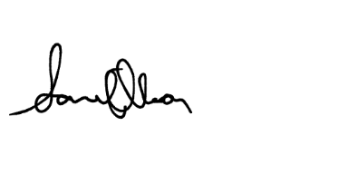

Samuel Olson